# Cluster Report: ISSDA, 16 clusters

Universidad de Deusto (carlos.quesada@deusto.es)

2022-03-03 09:39:13

#### List of abbreviations

##### Sets of features

- **sAggrDRM**: seasonal aggregates v2.0 (day-referenced mean)
- **sAggrP6**: seasonal aggregates v3.0 (6-period time division)

##### Datasets

- **goi**: GoiEner (including Megara and La Corriente) [ES]
- **lcl**: Low Carbon London [GB]
- **iss**: Irish Social Science Data Archive (ISSDA) [IE]
- **por**: Elergone Energia [PT]
- **nee**: Northwest Energy Efficiency Alliance (NEEA) [US]
- **Nds**: N datasets put together

##### Clustering methods

- **som**: self-organizing maps

##### Statistic used

- **μ**: mean
- **σ**: standard deviation

## sAggrDRM > iss > som

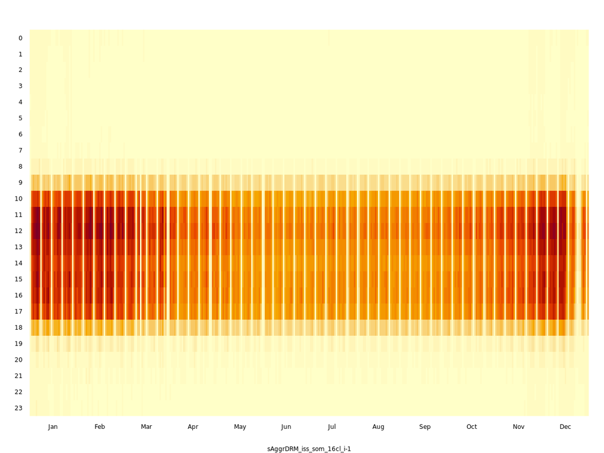

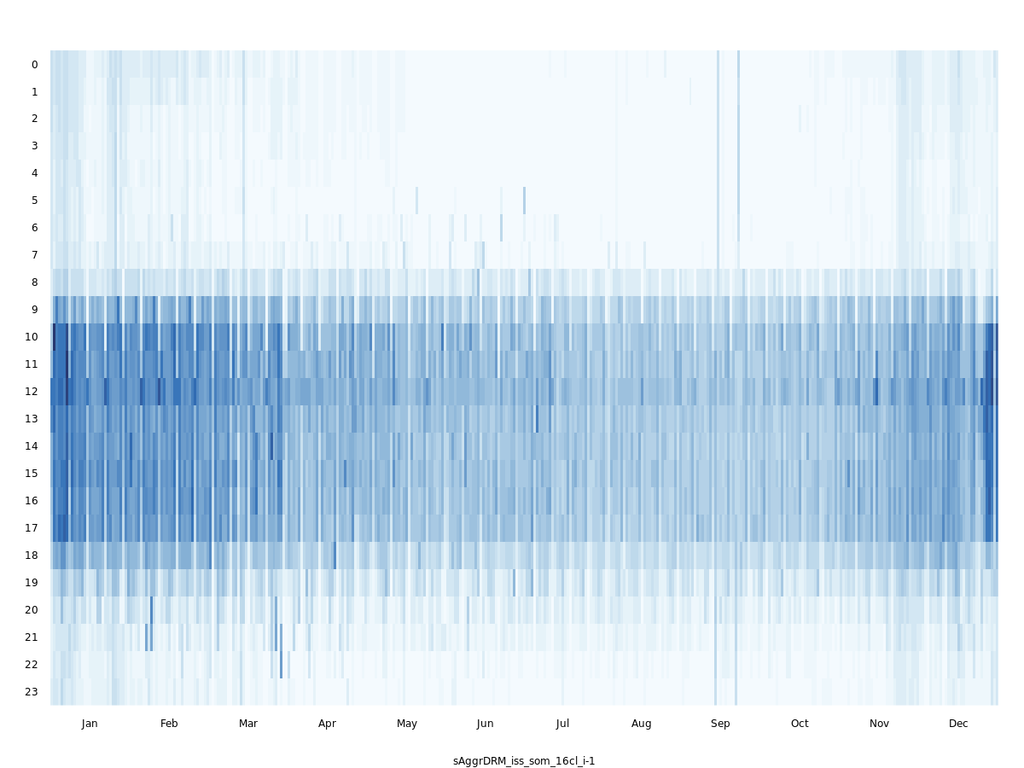

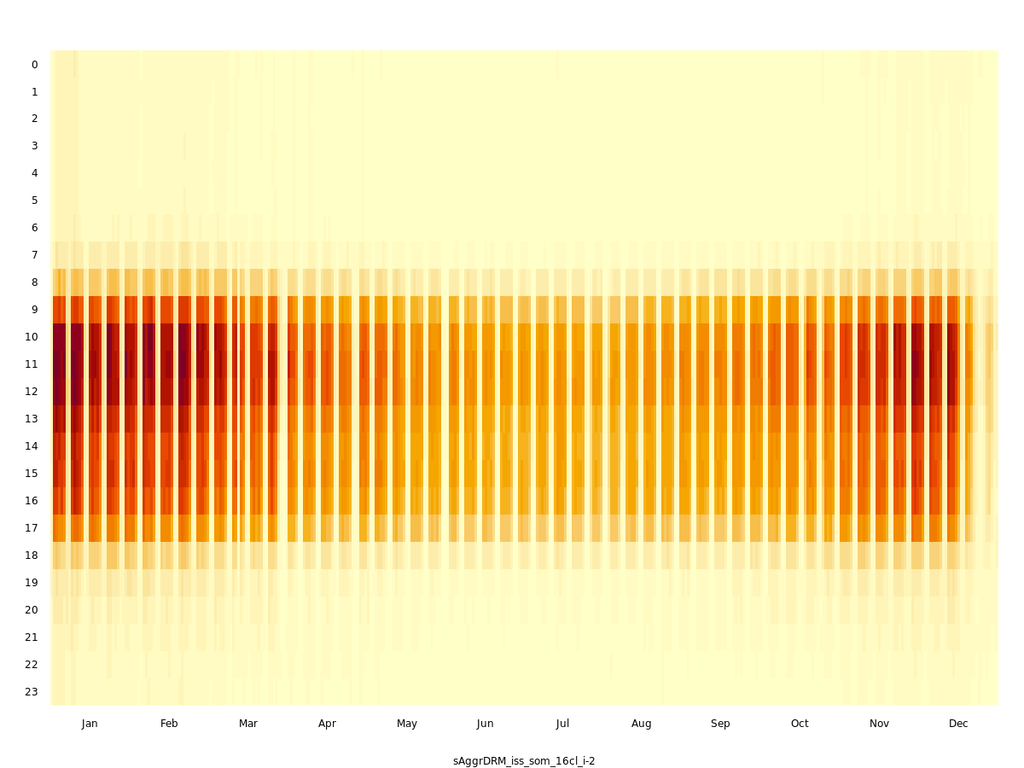

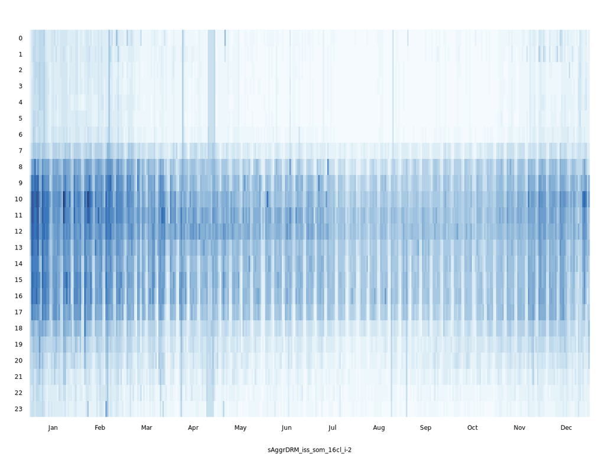

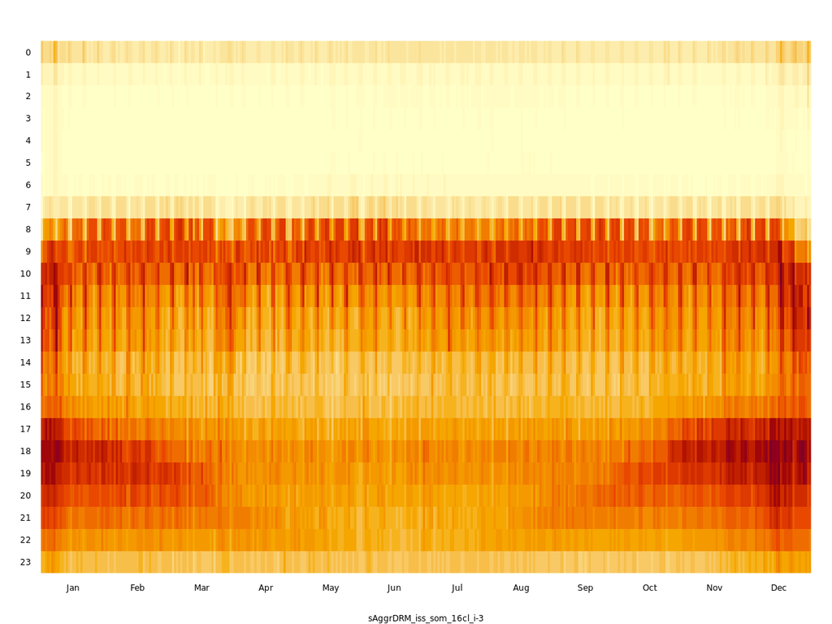

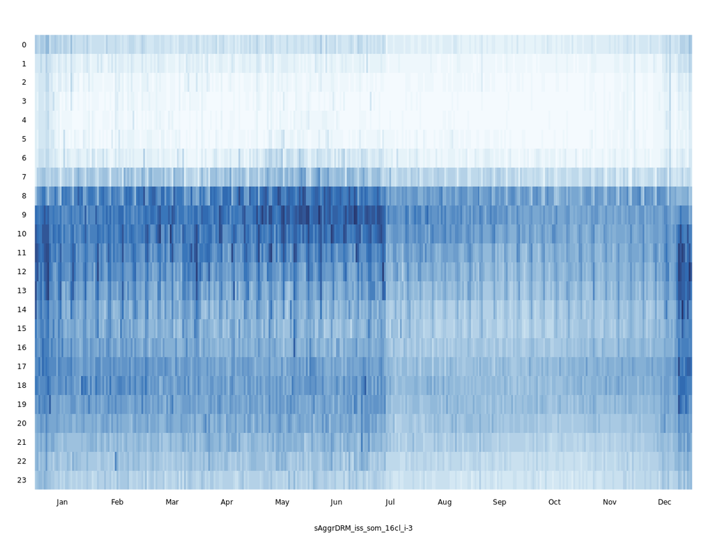

sAggrDRM > iss > som > μ > #1

108 TS (1.8%)

sAggrDRM > iss > som > σ > #1

108 TS (1.8%)

sAggrDRM > iss > som > μ > #2

196 TS (3.2%)

sAggrDRM > iss > som > σ > #2

196 TS (3.2%)

sAggrDRM > iss > som > μ > #3

388 TS (6.4%)

sAggrDRM > iss > som > σ > #3

388 TS (6.4%)

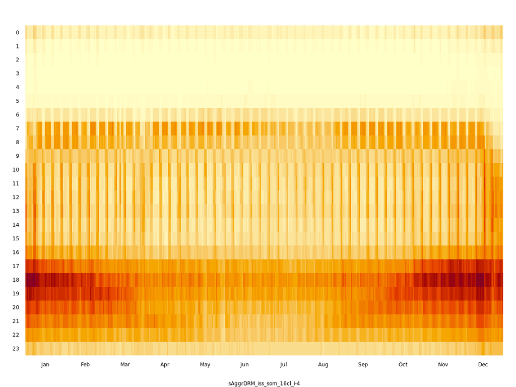

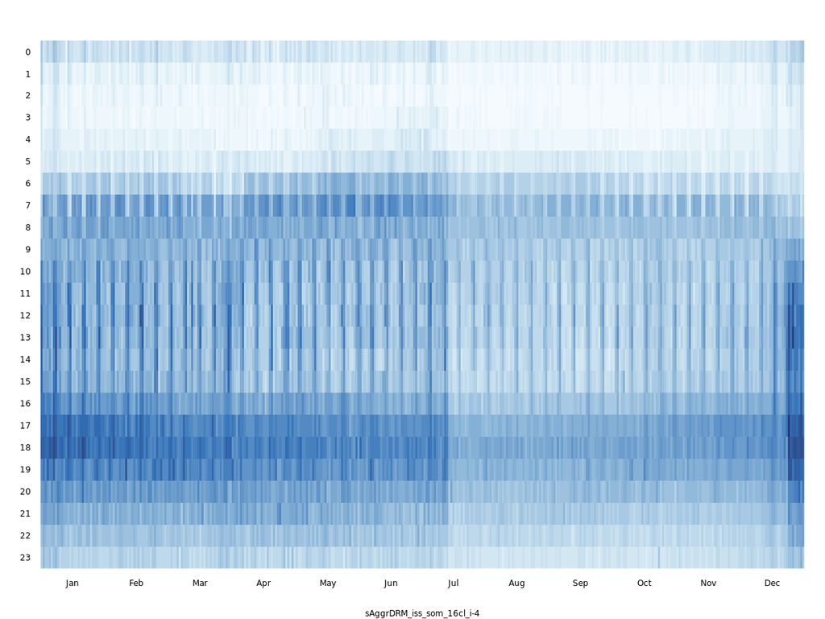

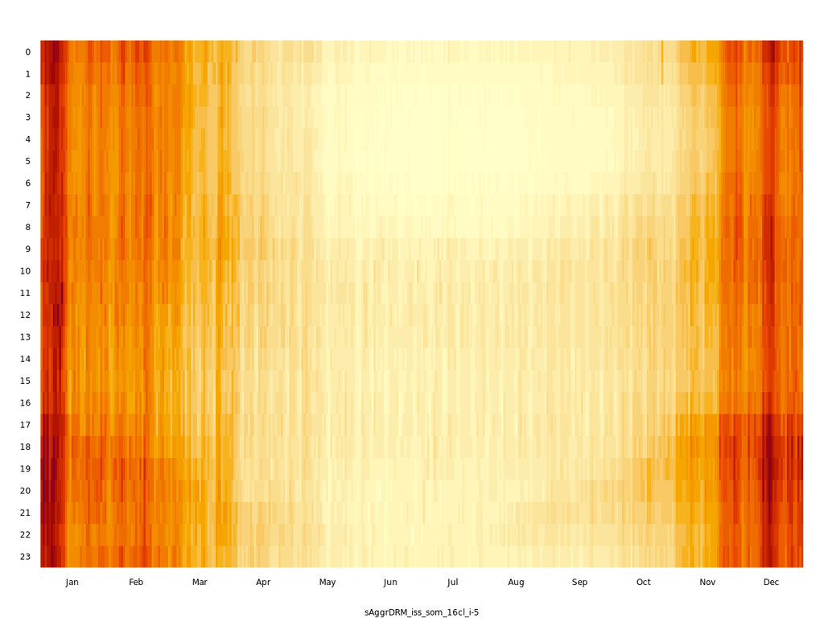

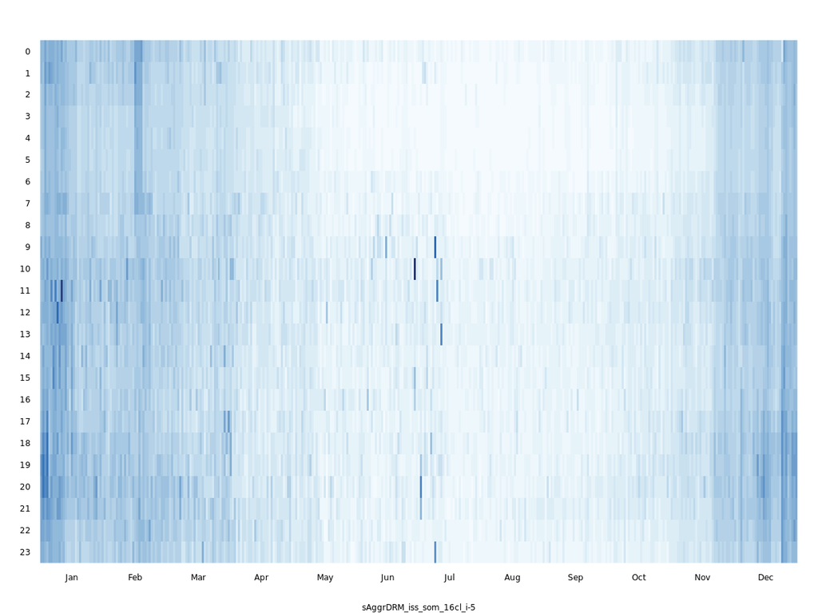

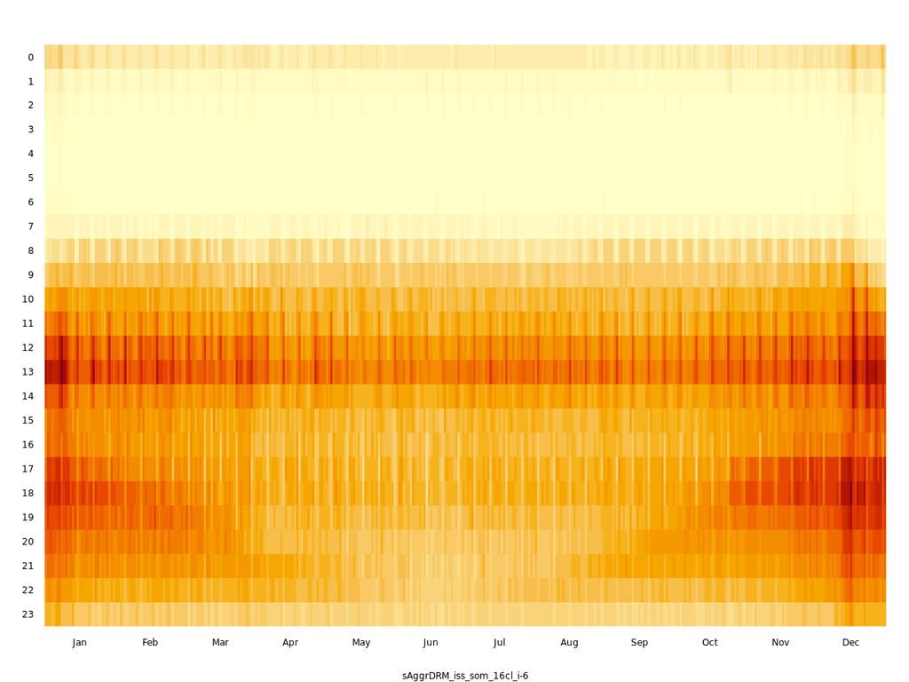

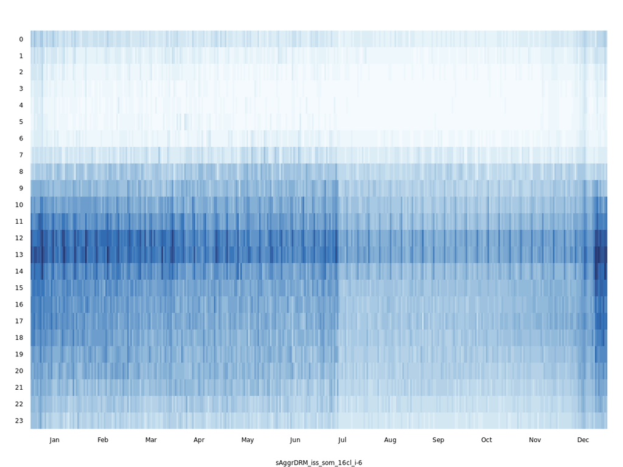

sAggrDRM > iss > som > μ > #4

403 TS (6.7%)

sAggrDRM > iss > som > σ > #4

403 TS (6.7%)

sAggrDRM > iss > som > μ > #5

146 TS (2.4%)

sAggrDRM > iss > som > σ > #5

146 TS (2.4%)

sAggrDRM > iss > som > μ > #6

434 TS (7.2%)

sAggrDRM > iss > som > σ > #6

434 TS (7.2%)

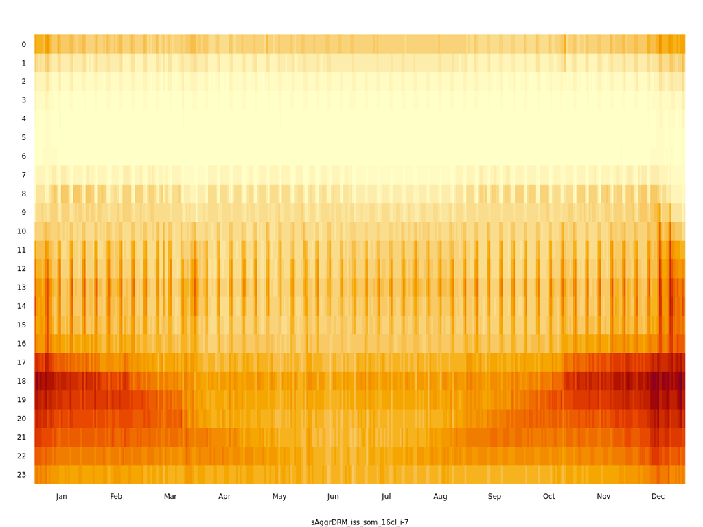

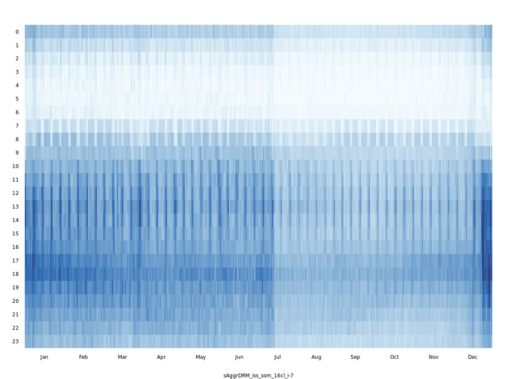

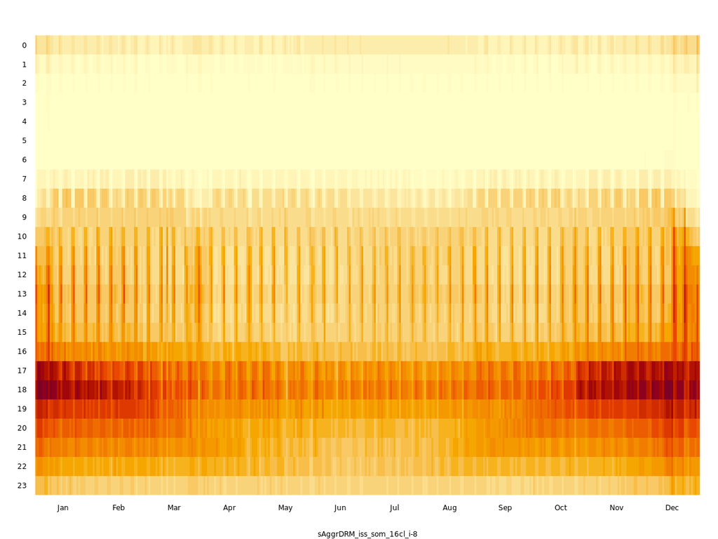

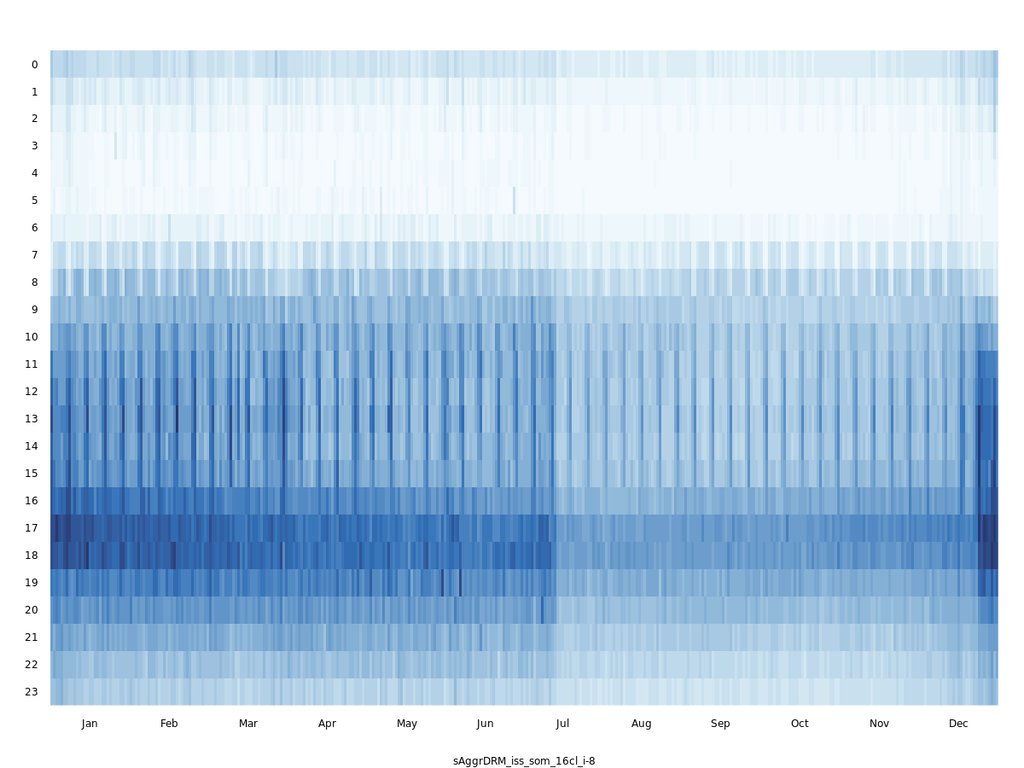

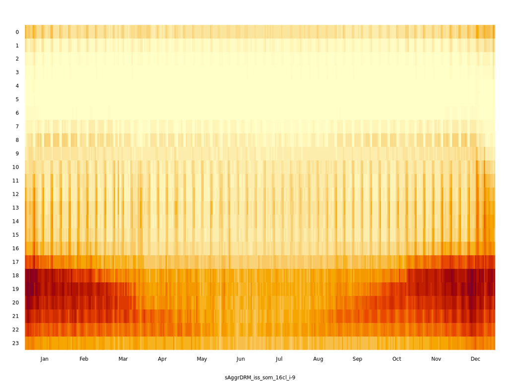

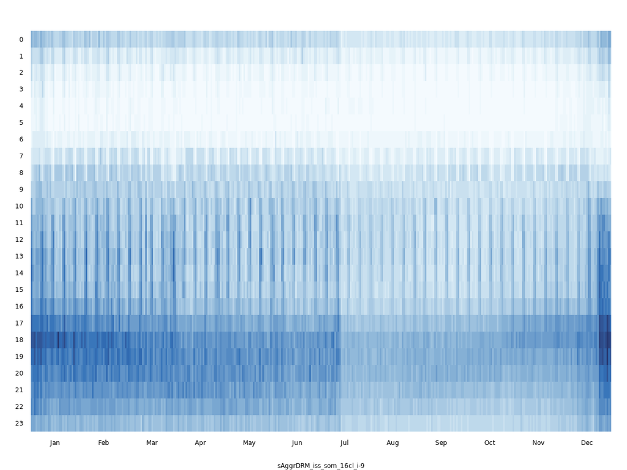

sAggrDRM > iss > som > μ > #7

1054 TS (17.4%)

sAggrDRM > iss > som > σ > #7

1054 TS (17.4%)

sAggrDRM > iss > som > μ > #8

646 TS (10.7%)

sAggrDRM > iss > som > σ > #8

646 TS (10.7%)

sAggrDRM > iss > som > μ > #9

522 TS (8.6%)

sAggrDRM > iss > som > σ > #9

522 TS (8.6%)

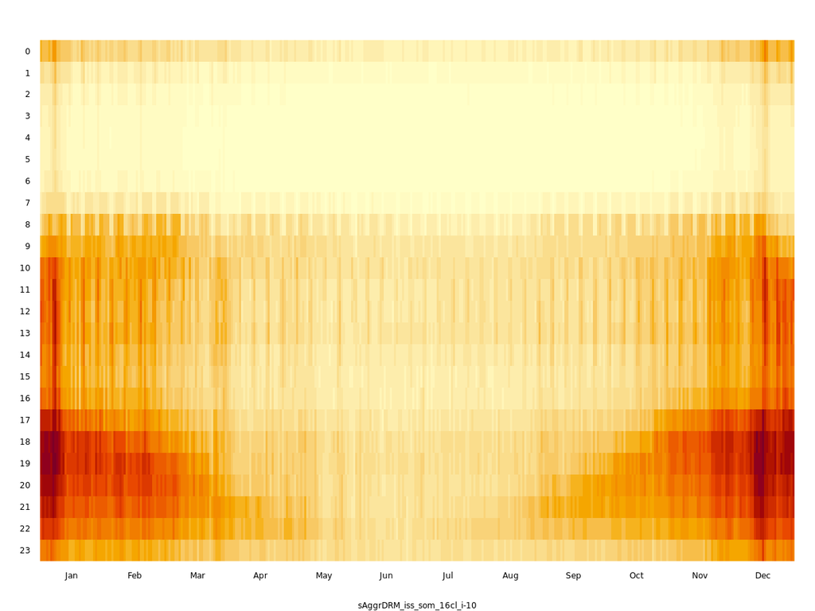

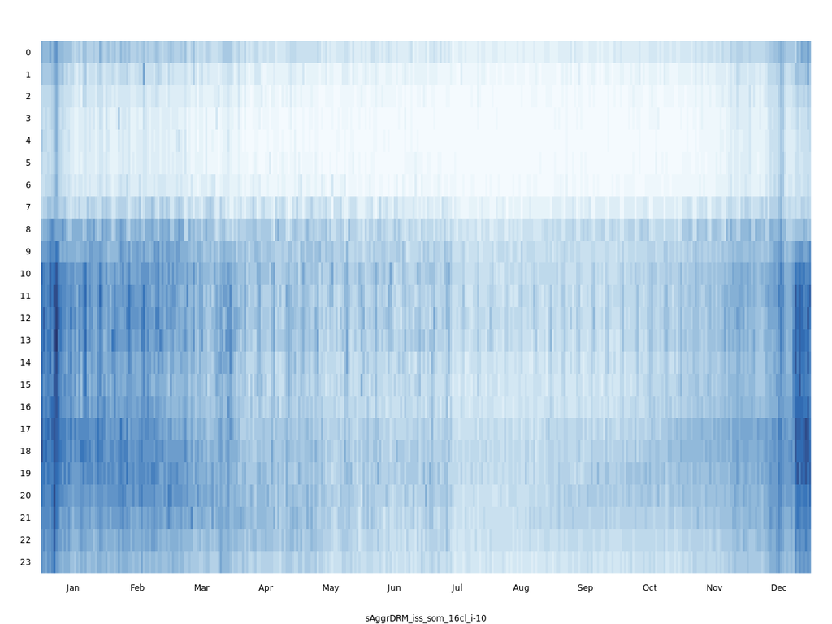

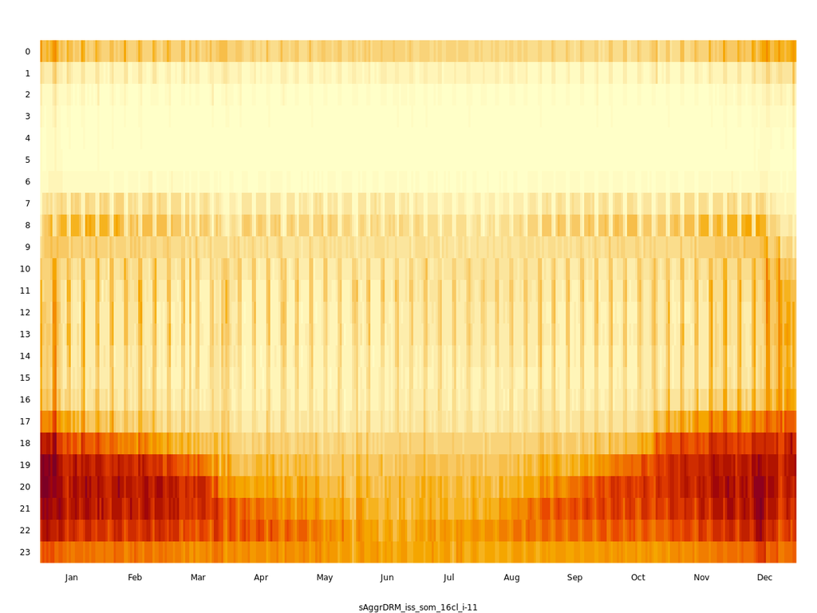

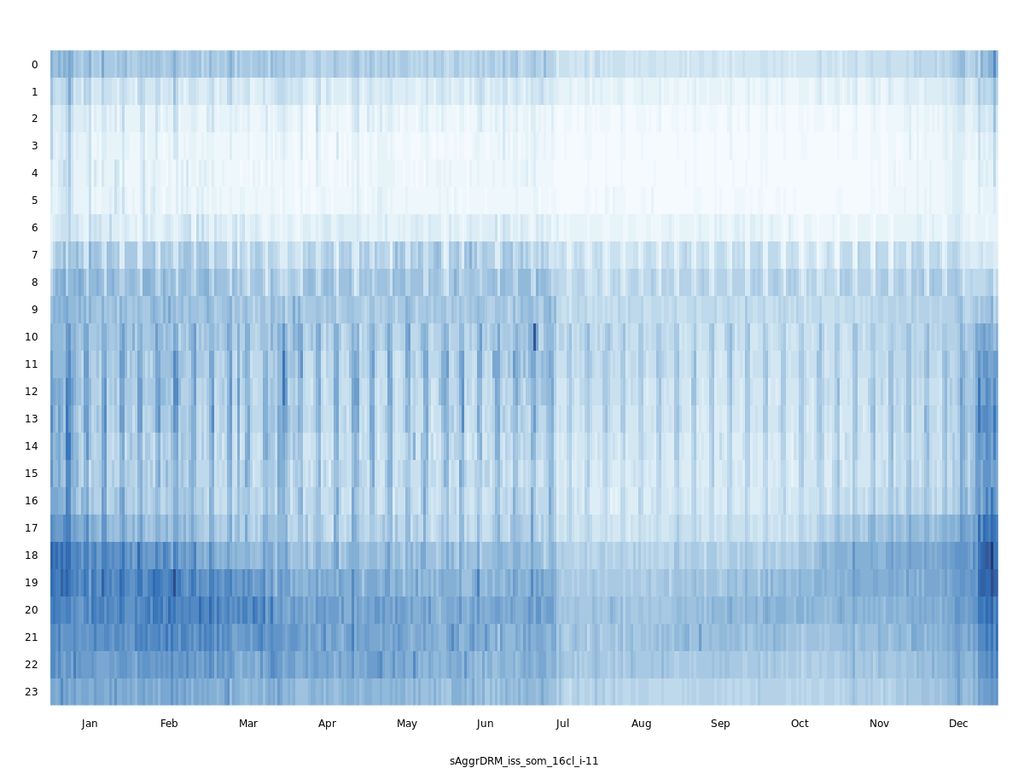

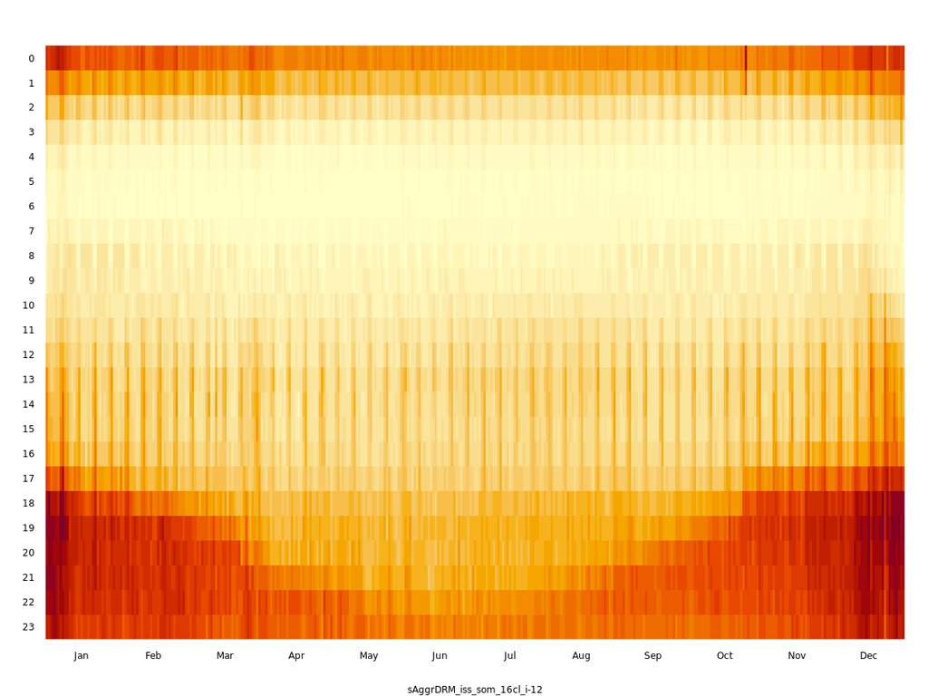

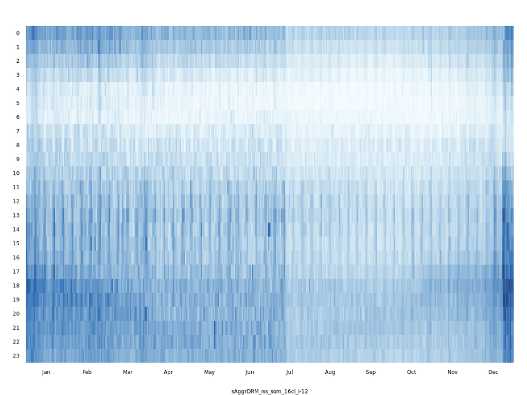

sAggrDRM > iss > som > μ > #10

387 TS (6.4%)

sAggrDRM > iss > som > σ > #10

387 TS (6.4%)

sAggrDRM > iss > som > μ > #11

522 TS (8.6%)

sAggrDRM > iss > som > σ > #11

522 TS (8.6%)

sAggrDRM > iss > som > μ > #12

431 TS (7.1%)

sAggrDRM > iss > som > σ > #12

431 TS (7.1%)

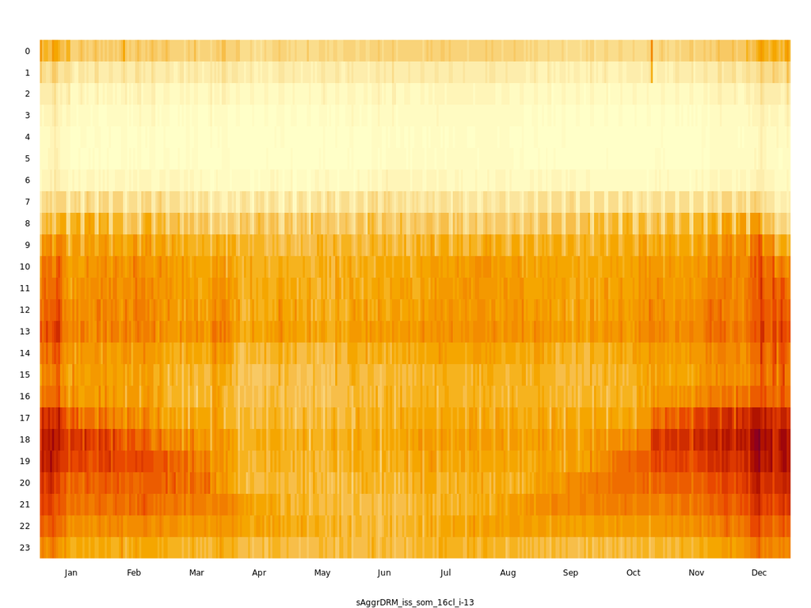

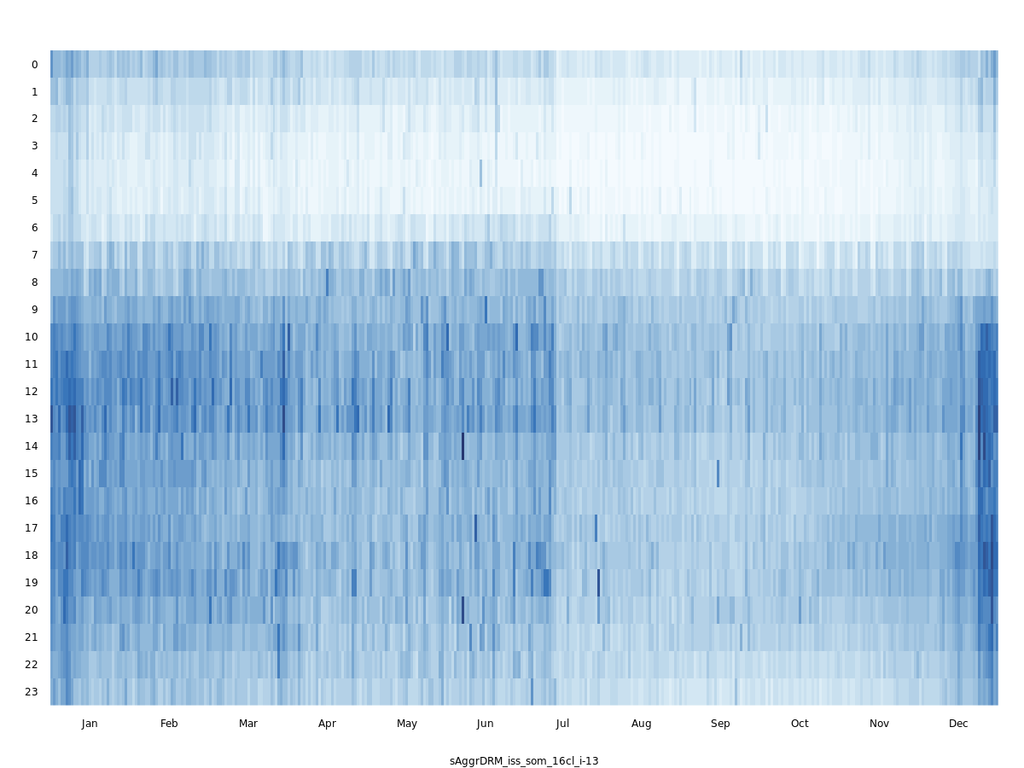

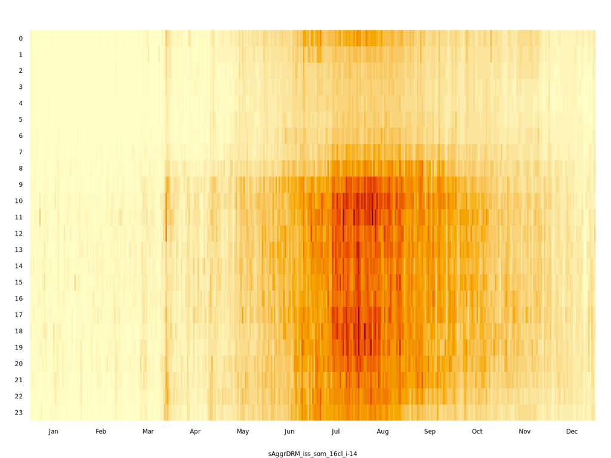

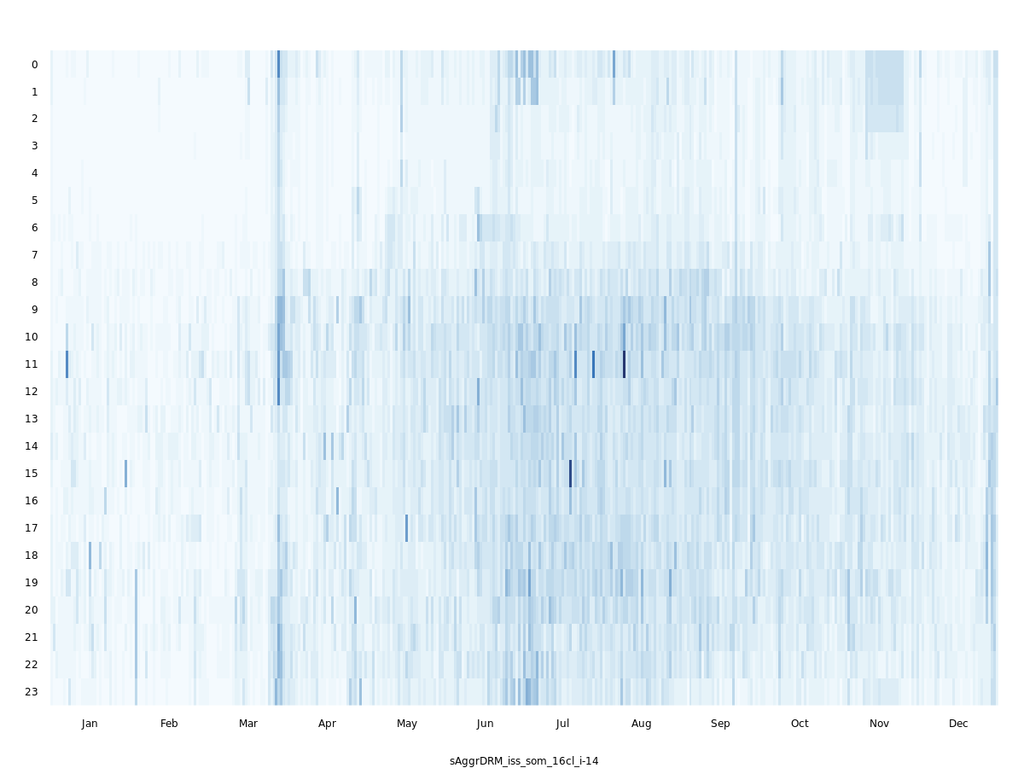

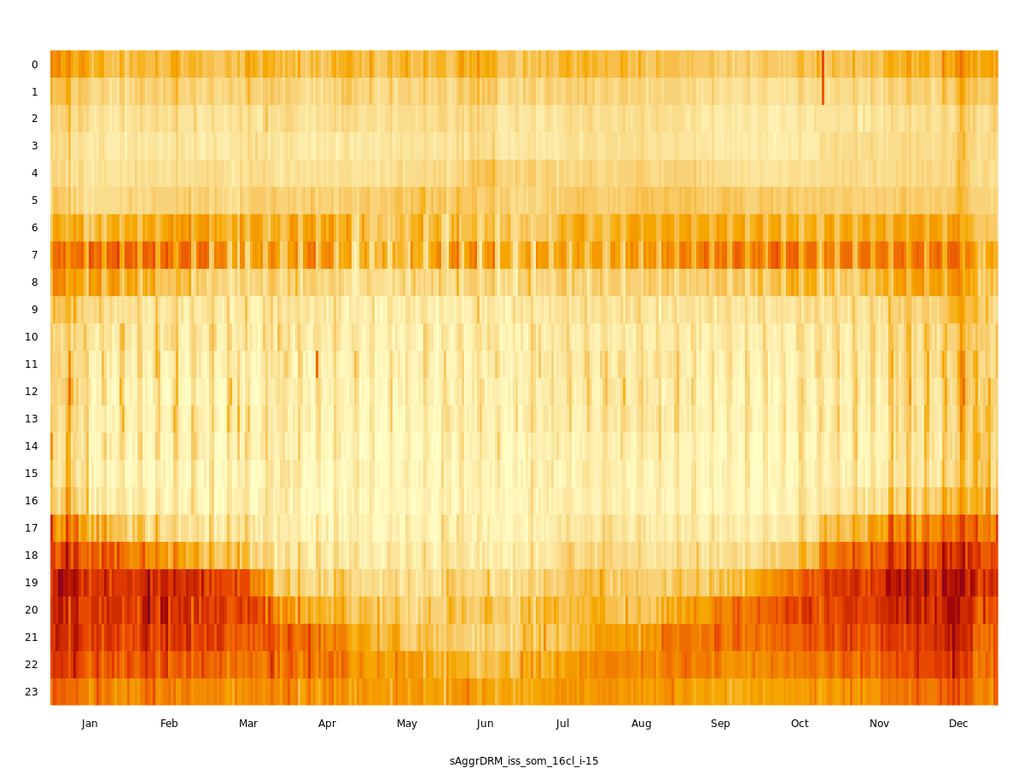

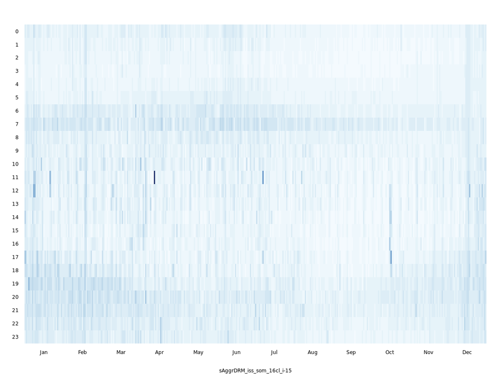

sAggrDRM > iss > som > μ > #13

545 TS (9%)

sAggrDRM > iss > som > σ > #13

545 TS (9%)

sAggrDRM > iss > som > μ > #14

56 TS (0.9%)

sAggrDRM > iss > som > σ > #14

56 TS (0.9%)

sAggrDRM > iss > som > μ > #15

153 TS (2.5%)

sAggrDRM > iss > som > σ > #15

153 TS (2.5%)

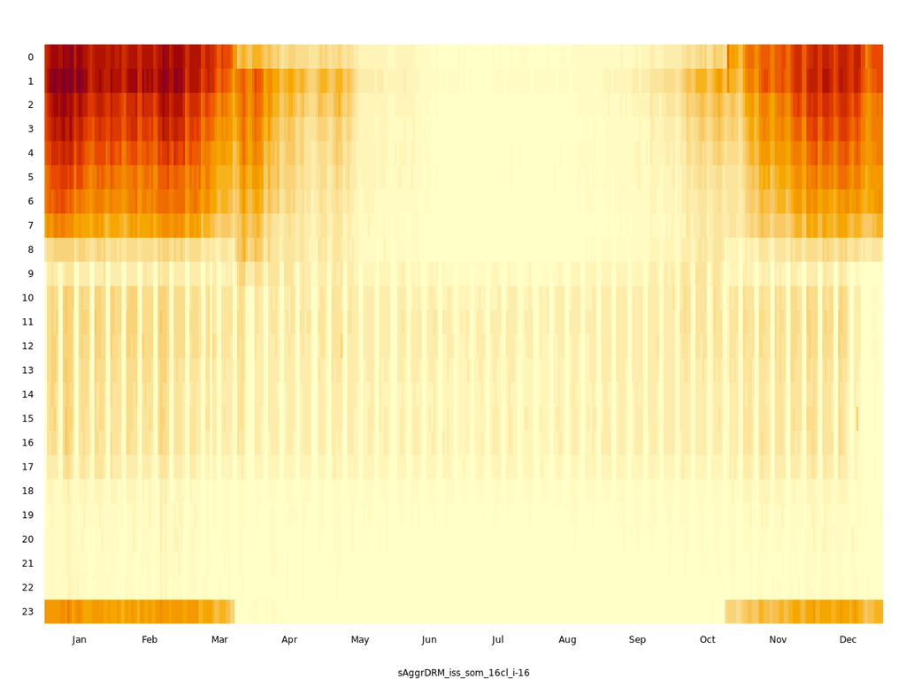

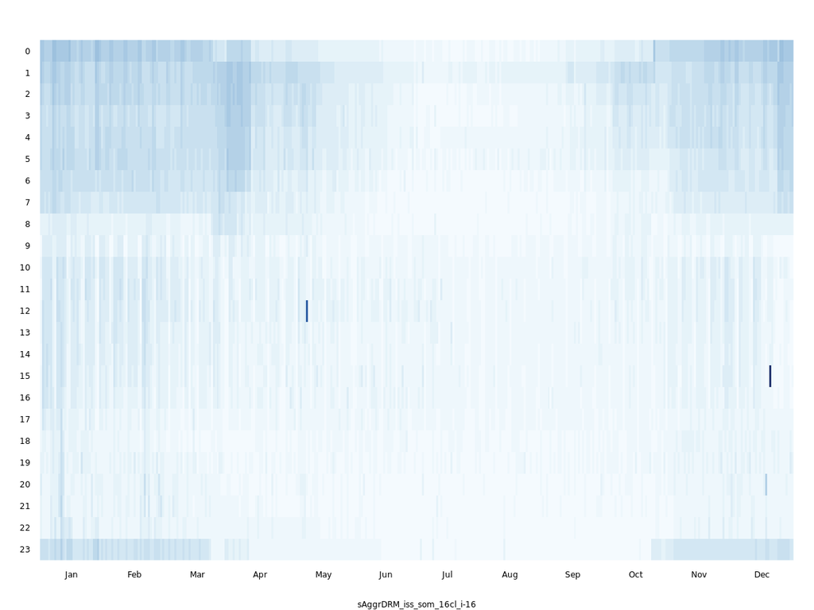

sAggrDRM > iss > som > μ > #16

52 TS (0.9%)

sAggrDRM > iss > som > σ > #16

52 TS (0.9%)